# Association results under smoking-specific variance model

Andrey Ziyatdinov

2017-06-27

# 1 About

## 1.1 Models

[output not shown]

Notes on the models

## 1.2 Summary of results

Marginal scans

- When incorporating the heterogeneity of residual errors, `smk0` models
  - More variance is explained and, thus, the attenuation of signals is observed (more power).
  - The inflation is on the same level.
- By adding an additional random term to describe the **genetic** heterogeneity, `arm_by_smk` model
  - Overfitting and some loss of power

Interaction scans

- Incorporating the heterogeneity of residual errors into `TwoRE` model removes the most of inflation.

## 1.3 TODO

- We need to incorporate the LRT to select between `TwoRE` and `arm_by_smk` models.
  - We observe empirically that `arm_by_smk` decreases the inflation from 1.19 to 1.05 for `FEV1_FVC1` trait.
  - Though, `arm_by_smk` increases the inflation from 1.09 to 1.14 for `FEV1pp` trait.
  - See the last figure in the report.
- Still to decide which tool, `lme4qtl` or `sommer` , to use.

# 2 Marginal scans

## 2.1 Variance proportion in `arm`

Variance proportion estimated by sommer (the defaul method: NR, constraints):

| trait | var_prop_sid | var_prop_ccenter | var_prop_Residual |
| --- | --- | --- | --- |
| FEV1_FVC_utah | 0.011 | 0.052 | 0.94 |
| FEV1pp_utah | 0.011 | 0.058 | 0.93 |
| FEV1_utah | 0.01 | 0.047 | 0.94 |
| FVCpp_utah | 0.006 | 0.035 | 0.96 |
| FVC_utah | 0.0072 | 0.033 | 0.96 |
| log_pctEmph_Slicer | 0.012 | 0.036 | 0.76 |
| TLCpp_race_adjusted | 0.017 | 0.033 | 0.95 |

Variance proportion estimated by lme4qtl:

| trait | var_prop_sid | var_prop_ccenter | var_prop_Residual |
| --- | --- | --- | --- |
| FEV1_FVC_utah | 0.011 | 0.052 | 0.94 |
| FEV1pp_utah | 0.011 | 0.058 | 0.93 |
| FEV1_utah | 0.01 | 0.047 | 0.94 |
| FVCpp_utah | 0.006 | 0.035 | 0.96 |
| FVC_utah | 0.0072 | 0.033 | 0.96 |
| log_pctEmph_Slicer | 0.012 | 0.036 | 0.76 |
| TLCpp_race_adjusted | 0.017 | 0.033 | 0.95 |

## 2.2 Variance proportion in `arm_smk0`

Variance proportion estimated by sommer:

| trait | var_prop_sid | var_prop_ccenter | var_prop_smk0 | var_prop_Residual |
| --- | --- | --- | --- | --- |
| FEV1_FVC_utah | 0.0049 | 0.017 | 0.59 | 0.39 |
| FEV1pp_utah | 0.0098 | 0.034 | 0.44 | 0.52 |
| FEV1_utah | 0.0096 | 0.031 | 0.37 | 0.59 |
| FVCpp_utah | 0.0075 | 0.025 | 0.32 | 0.64 |
| FVC_utah | 0.0078 | 0.027 | 0.24 | 0.72 |
| log_pctEmph_Slicer | 0.0073 | 0.023 | 0.31 | 0.52 |
| TLCpp_race_adjusted | 0.013 | 0.021 | 0.29 | 0.68 |

## 2.3 Marginal scans

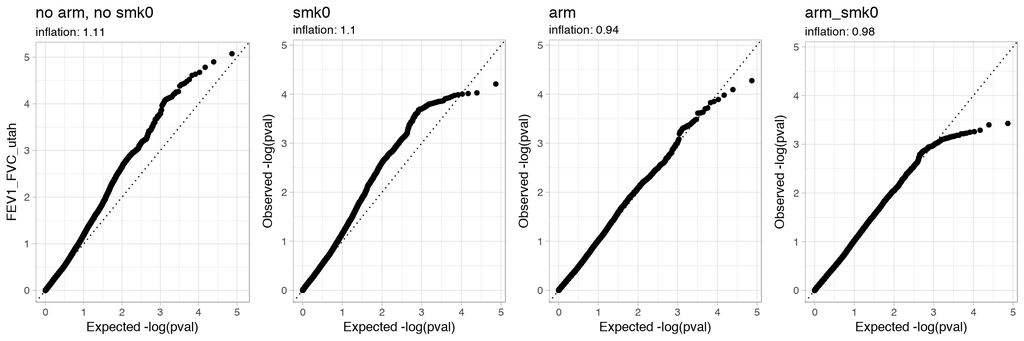

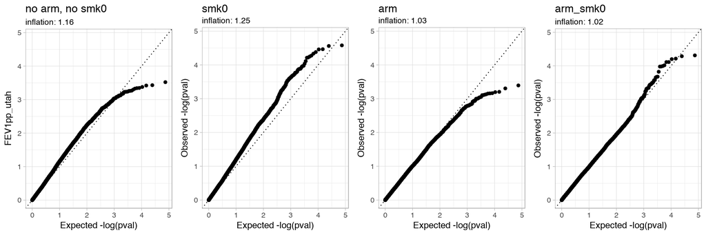

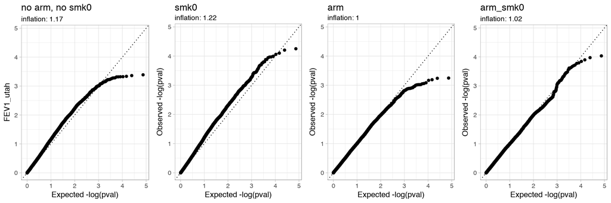

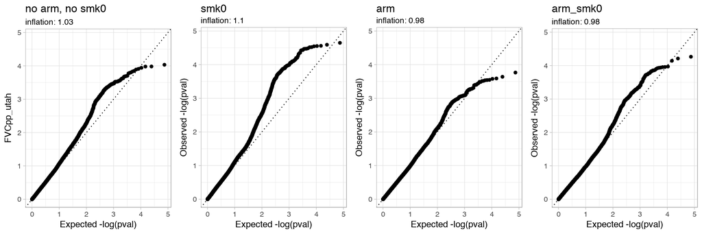

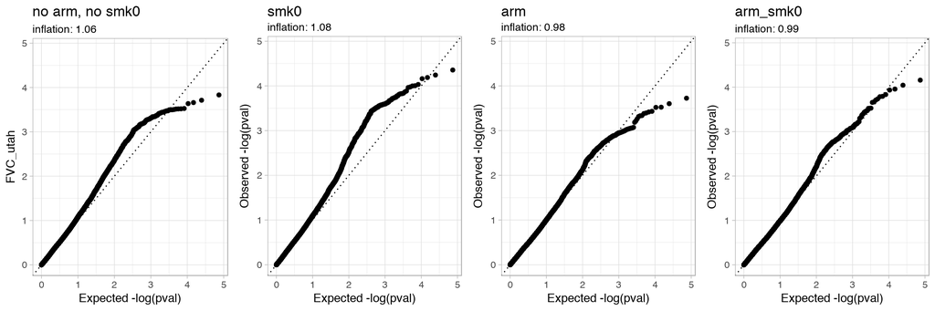

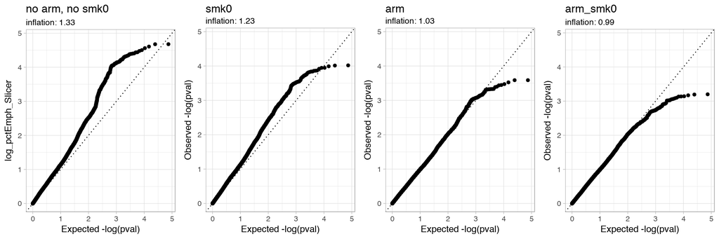

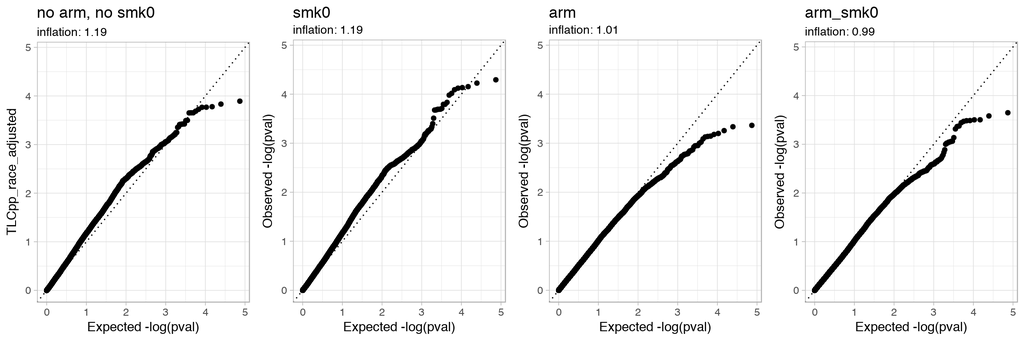

## 2.4 Marginal scans based on `arm_by_smk` model

Variance proportion estimated by lme4qtl:

| trait | var_prop_sid_0 | var_prop_sid_1 | var_prop_sid_01 | var_prop_ccenter | var_prop_smk0 | var_prop_Residual |
| --- | --- | --- | --- | --- | --- | --- |
| FEV1_FVC_utah | 0.038 | 0.0041 | 0.0058 | NA | 0.56 | 0.39 |
| FEV1pp_utah | 0 | 0.014 | 0 | NA | 0.47 | 0.52 |
| FEV1_utah | 0 | 0.014 | 0 | NA | 0.39 | 0.59 |
| FVCpp_utah | 0.0042 | 0.017 | -0.0085 | NA | 0.35 | 0.64 |
| FVC_utah | 0.0022 | 0.018 | -0.0062 | NA | 0.26 | 0.72 |
| log_pctEmph_Slicer | 0.087 | 0.0037 | 0.018 | NA | 0.26 | 0.63 |
| TLCpp_race_adjusted | 0.031 | 0.014 | 0.013 | NA | 0.28 | 0.66 |

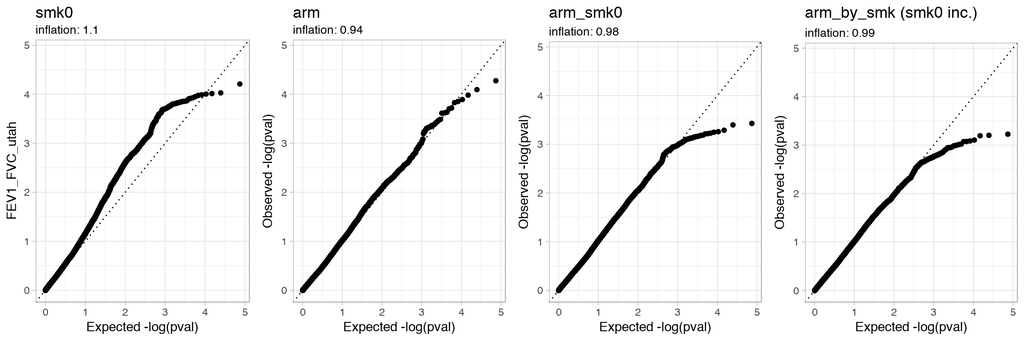

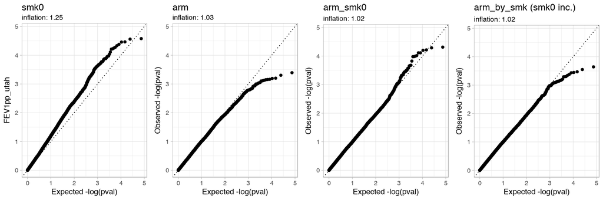

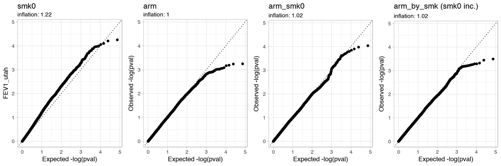

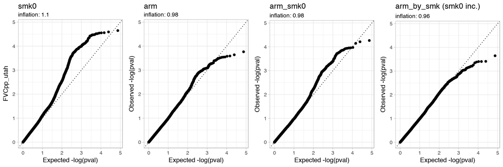

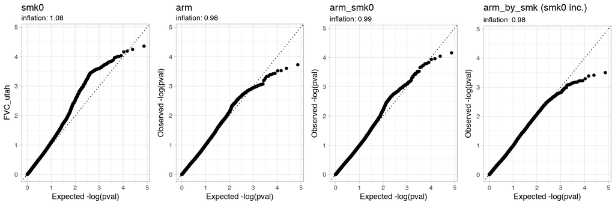

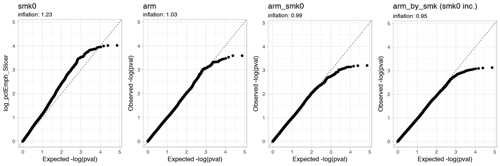

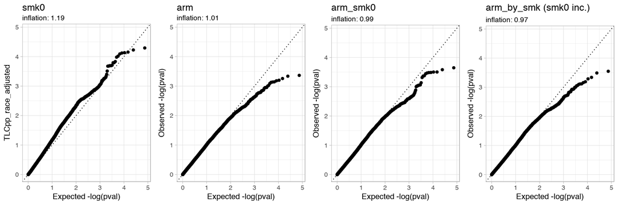

# 3 Interaction scans

Variance proportion estimated by sommer (the defaul method: NR, constraints) in (0) `TwoRE` model:

| trait | var_prop_sid | var_prop_esid | var_prop_ccenter | var_prop_Residual |
| --- | --- | --- | --- | --- |
| FEV1_FVC_utah | 0.005274 | 0.01498 | 0.05345 | 0.9263 |
| FEV1pp_utah | 0 | 0.03627 | 0.05624 | 0.9075 |
| FEV1_utah | 0 | 0.0289 | 0.04601 | 0.9251 |
| FVCpp_utah | 0 | 0.03691 | 0.03286 | 0.9302 |
| FVC_utah | 0 | 0.03031 | 0.03179 | 0.9379 |
| log_pctEmph_Slicer | 0.00869 | 0.006287 | 0.03707 | 0.7593 |
| TLCpp_race_adjusted | 0.01397 | 0.005357 | 0.03311 | 0.9476 |

Variance proportion estimated by sommer in `TwoRE + smk0`:

| trait | var_prop_sid | var_prop_esid | var_prop_ccenter | var_prop_smk | var_prop_smk0 | var_prop_Residual |
| --- | --- | --- | --- | --- | --- | --- |
| FEV1_FVC_utah | 0.003889 | 0 | 0.01351 | 0.2175 | 0.4596 | 0.3055 |
| FEV1pp_utah | 0 | 0.01423 | 0.02508 | 0.2523 | 0.3239 | 0.3844 |
| FEV1_utah | 0 | 0.01301 | 0.02224 | 0.2733 | 0.2671 | 0.4244 |
| FVCpp_utah | 0 | 0.01847 | 0.01745 | 0.276 | 0.232 | 0.4561 |
| FVC_utah | 0 | 0.01646 | 0.01797 | 0.2997 | 0.1662 | 0.4997 |
| log_pctEmph_Slicer | 0.006496 | 0 | 0.01803 | 0.2446 | 0.2301 | 0.395 |
| TLCpp_race_adjusted | 0.008822 | 0 | 0.01481 | 0.3 | 0.2014 | 0.4749 |

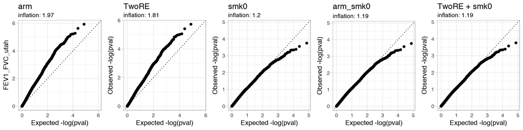

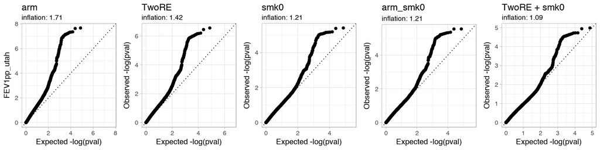

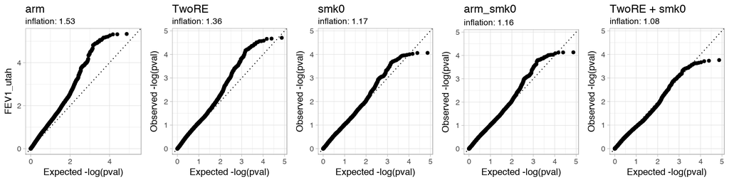

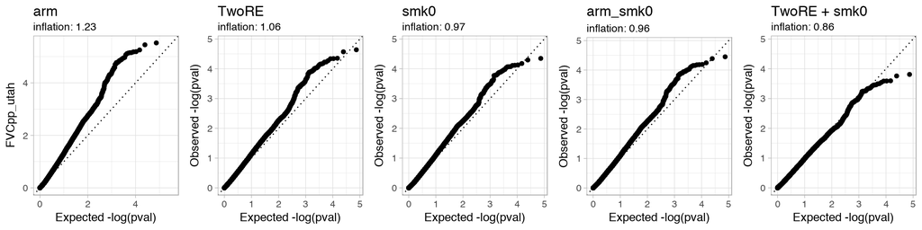

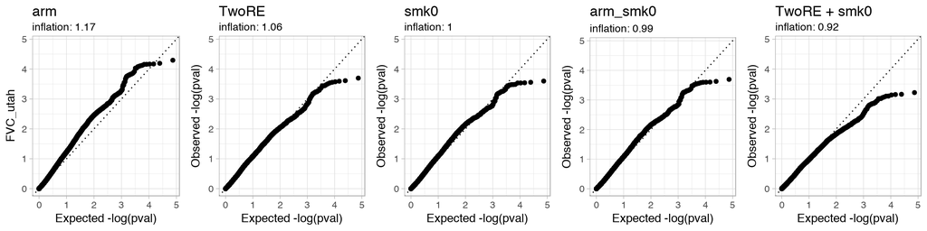

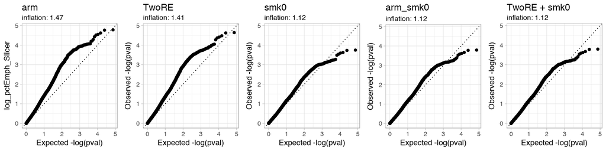

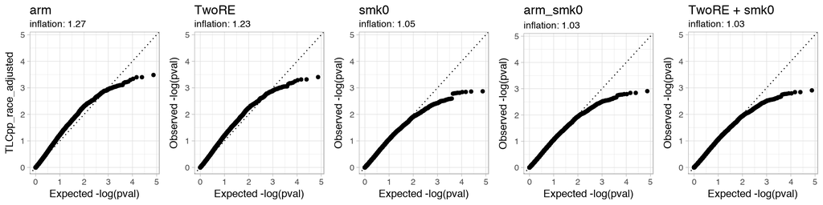

## 3.1 Interaction scans based on `arm_by_smk` model

Variance proportion estimated by lme4qtl:

| trait | var_prop_sid_0 | var_prop_sid_1 | var_prop_sid_01 | var_prop_ccenter | var_prop_smk0 | var_prop_Residual |
| --- | --- | --- | --- | --- | --- | --- |
| FEV1_FVC_utah | 0.038 | 0.0041 | 0.0058 | NA | 0.56 | 0.39 |
| FEV1pp_utah | 0 | 0.014 | 0 | NA | 0.47 | 0.52 |
| FEV1_utah | 0 | 0.014 | 0 | NA | 0.39 | 0.59 |
| FVCpp_utah | 0.0042 | 0.017 | -0.0085 | NA | 0.35 | 0.64 |
| FVC_utah | 0.0022 | 0.018 | -0.0062 | NA | 0.26 | 0.72 |
| log_pctEmph_Slicer | 0.087 | 0.0037 | 0.018 | NA | 0.26 | 0.63 |
| TLCpp_race_adjusted | 0.031 | 0.014 | 0.013 | NA | 0.28 | 0.66 |

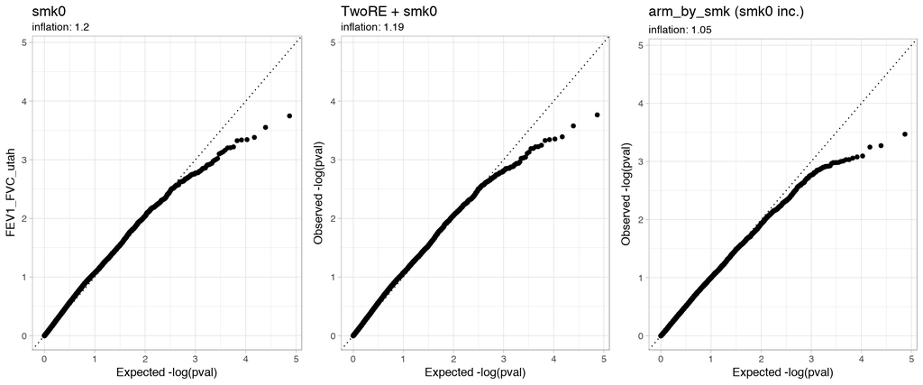

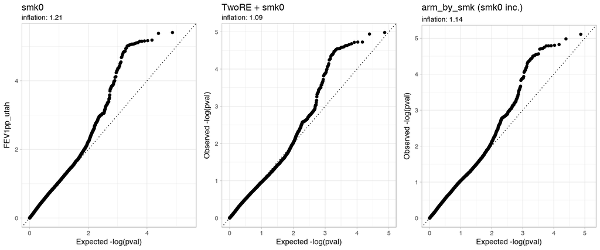

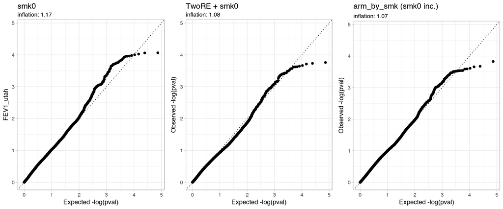

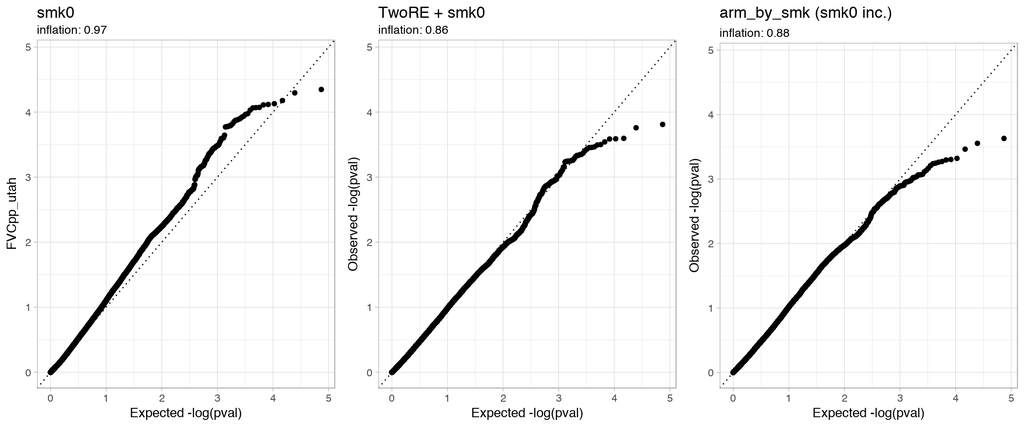

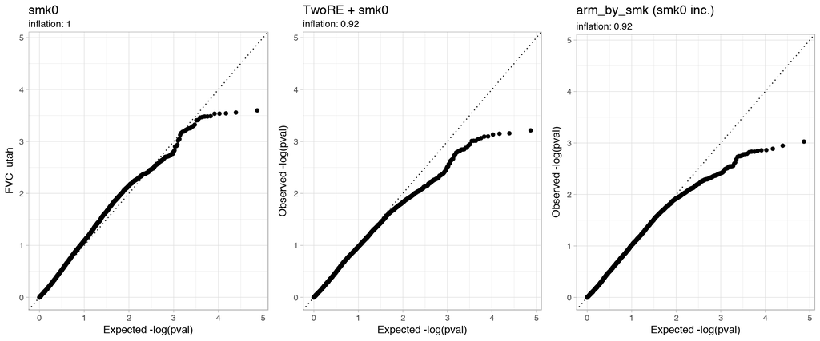

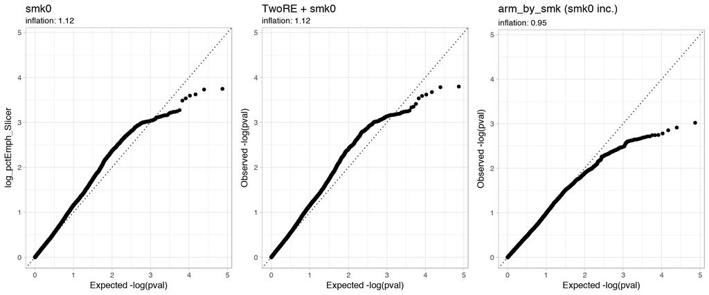

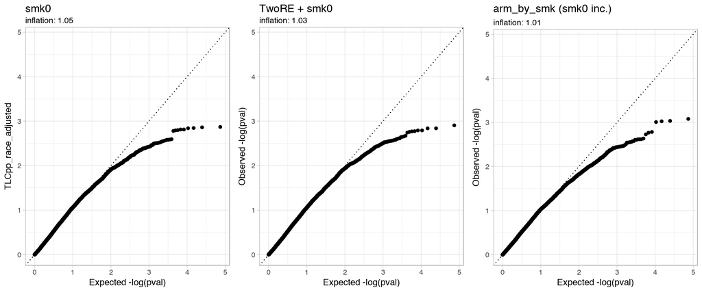

# References

Blangero, John. 2009. “Statistical Genetic Approaches to Human Adaptability.” *Human Biology* 65 (6). BioOne: 523–46.

Sul, Jae Hoon, Michael Bilow, Wen-Yun Yang, Emrah Kostem, Nick Furlotte, Dan He, and Eleazar Eskin. 2016. “Accounting for Population Structure in Gene-by-Environment Interactions in Genome-Wide Association Studies Using Mixed Models.” *PLoS Genetics* 12 (3): e1005849. doi:10.1371/journal.pgen.1005849.